# Comunicar con RStudio

*Unidad 8*

basado en tom mock, mine centikaya  
y elaboración propia. artwork por allison horst

## Qué es Quarto®?

> **Quarto® es un nuevo sistema de publicación científica y técnica de código abierto construido sobre [Pandoc](https://pandoc.org/)** <sup>1</sup>

> Mezcla texto narrativo y código para producir resultados con un formato elegante en documentos, tableros interactivos, páginas web, publicaciones de blogs, libros y más.

> Es independiente del lenguaje R (incluso trabaja con otros lenguajes como Python y Julia).
[^1]: conversor de documentos libre y de código abierto, mayormente usado como una herramienta de escritura (especialmente por académicos) ver en [Wikipedia](https://es.wikipedia.org/wiki/Pandoc)

## Comunicar como parte de programar

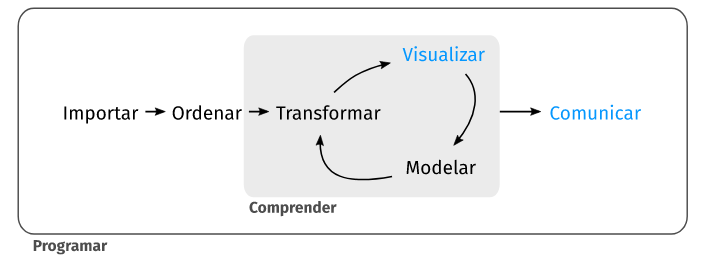

## Ecosistema de RMarkdown

[figure not shown]

## RMarkdown en Rstudio

- Desarrollo del paquete **knitr** desde 2011
- Desarrollo de **RMarkdown** desde 2014 (rmarkdown + pandoc)
- 10 años de experiencia en `knitr` + `rmarkdown` se volcaron al desarrollo de Quarto.

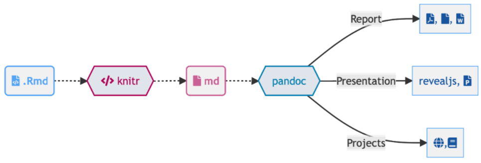

## Como funciona Quarto?

[figure not shown]

## Como funciona Quarto?

Quarto usa `knitr` o `jupyter` como motor para ejecutar código y generar una salida temporal (**.md**).

El archivo temporal se procesa mediante los filtros **Lua** de `Pandoc` y `Quarto` + `Bootstrap CSS` para **HTML** o `LaTeX` para **PDF** y se convierte a un formato de salida final.

Los filtros Lua escritos por desarrolladores de `R`/`Python`/`Julia` son intercambiables entre formatos.

Quarto además incluye soporte nativo para `Observable JS`, un conjunto de mejoras a JavaScript básico creado por *Mike Bostock* (también autor de `D3`).

Observable JS se distingue por su tiempo de ejecución reactivo, que es especialmente adecuado para la exploración y el análisis de datos interactivos.

## Ejemplo interactivo con Observable JS

Conversor de temperatura de ℃ a ℉

[interactive chart not shown]

Celsius = ℃ y Fahrenheit = ℉.

````markdown
```{ojs}
viewof temp = Inputs.range([0, 99], {step: 1, value: 0, label: htl.html`Temp. &#x2103;`})
```
Celsius = \${d3.format(".0f")(temp)}℃ y Fahrenheit = \${d3.format(".1f")(temp \* 9/5 + 32)}℉.
````

## Entonces, ¿qué es Quarto?

> Quarto es una interfaz de *línea de comandos* (**CLI**) que representa formatos de texto sin formato (**.qmd**, .rmd, .md) o formatos mixtos (**.ipynb**/Jupyter notebook) en informes estáticos *PDF*/*Word*/*HTML*, *libros*, *sitios web*, *presentaciones* y más.

```python
cballejo$ quarto --help

  Usage:   quarto
  Version: 1.9.38

  Description:
    Quarto CLI

  Options:
    -h, --help     - Show this help.
    -V, --version  - Show the version number for this program.

  Commands:
    render          [input] [args...]   - Render input file(s) to various document types.
    preview         [file] [args...]    - Render and preview a document or website project.
    serve           [input]             - Serve a Shiny interactive document.
    create-project  [dir]               - Create a project for rendering multiple documents
    convert         <input>             - Convert documents to alternate representations.
    pandoc          [args...]           - Run the version of Pandoc embedded within Quarto.
    run             [script] [args...]  - Run a TypeScript, R, Python, or Lua script.
    install         <type> [target]     - Installs an extension or global dependency.
    publish         [provider] [path]   - Publish a document or project. Available providers include:
    check           [target]            - Verify correct functioning of Quarto installation.
    help            [command]           - Show this help or the help of a sub-command.
```

## Software Quarto

- El sitio web de `Quarto` es https://quarto.org/
- La **versión actual** es 1.9.38 (Windows) del 25/05/2026
- La **guía oficial** se puede encontrar en https://quarto.org/docs/guide/
- **RStudio Desktop** incluye una versión de Quarto en su instalación desde la versión 2022.07.01 pero conviene actualizarlo de forma independiente

[figure not shown]

## Otras características

- Tiene múltiples formatos modernos de salidas unificado la funcionalidad de muchos paquetes del ecosistema R Markdown (rmarkdown, bookdown, distill, xaringan, etc.)
- Implementa funciones más atractivas y útiles en todos los productos: pestañas, resaltado de sintaxis, diagramas, etc.
- Se pueden renderizar los documentos viejos `.rmd` (RMarkdown) o `.ipynb` (cuadernos jupyter de python) con Quarto.
- Viene incluido en otros editores como VS Code
- Soporta `htmlwidgets` en R y Jupyter widgets para Python/Julia además de Observable JS

## Por qué usar Quarto en lugar de RMarkdown?

- Quarto no es muy diferente a **RMarkdown**, más bien es un RMarkdown de nueva generación (*next-generation*)
- Posee mejor accesibilidad y funciones más completas listas para usar
- **RMarkdown** aún tiene soporte pero todas las novedades y mejoras se están desarrollando solo para `Quarto`
- Si en el futuro incorporas algún otro lenguaje de programación/análisis podes seguir utilizandolo
- Podes elegir otros editores y `Quarto` seguirá funcionando

## El universo de Quarto es enorme

[figure not shown]

## Anatomia de un `.qmd`

Al igual que los **.Rmd** de **RMarkdown** el archivo fuente de `Quarto` es de texto plano

Tiene una cabecera `YAML` con metadatos

```yaml
format: html
engine: knitr
```

```yaml
format: html
engine: jupyter
```

Suele tener código incluido

````markdown
```{r}
library(dplyr)
mtcars |>
  group_by(cyl) |>
  summarize(mean = mean(mpg))
```
````

````markdown
```{python}
from siuba import *
(mtcars
  >> group_by(_.cyl)
  >> summarize(avg_mpg = _.mpg.mean()))
```
````

Y texto narrativo

```markdown
# Cabecera 1
Esto es texto en **negrita**, esto en *itálica* y esta otra una
![imagen](image.png){fig-alt="Texto alternativo para esta imagen"}.
```

## Ejemplo de un .qmd

Los archivos `.qmd` responden estructuralmente al modelo de programación literaria ([Literate programming](https://es.wikipedia.org/wiki/Programaci%C3%B3n_literaria))

````markdown
---
title: "ggplot2"
date: "18/04/2024"
format: html
---

## Calidad del aire

Esta es la relación entre la temperatura y el nivel de ozono.

```{r}
#| label: fig-calidad_aire
library(ggplot2)
ggplot(airquality, aes(Temp, Ozone)) +
  geom_point() +
  geom_smooth(method = "loess"
)
```
````

## Metadatos: YAML

- Los metadatos que se definen en el encabezado YAML que todos los archivos `.qmd` tienen son procesados en muchas etapas del renderizado y puede influir en el documento final de varias formas.
- Siempre se colocan al principio del documento y lo lee **Pandoc**, **Quarto** y **knitr**.
- En su recorrido, la información que contiene suele afectar el código, el contenido y el proceso de renderizado.
- Muchas de las opciones de código YAML para Quarto se pueden encontrar en su [documentación](https://quarto.org/docs/reference/)

## Texto y otros elementos

- `Quarto` se basa en **Pandoc** y utiliza su variación de Markdown como sintaxis para documentos.
- El **Markdown** de Pandoc es una versión ampliada y ligeramente revisada de la sintaxis Markdown de [John Gruber](https://en.wikipedia.org/wiki/John_Gruber).
- Markdown es un lenguaje de marcas sencillo diseñado para ser fácil de escribir y, lo que es más importante, fácil de leer.
- Es el mismo que se utiliza en el formato anterior de RMarkdown (archivos .Rmd)

## Código

- El código se puede insertar a través de chunks (fragmentos) en distintos lenguajes

````markdown
```{r}
#| Aquí van los metadatos con las opciones de ejecución

Aquí va el código
```
````

- Las opciones de ejecución del código incluido dentro de estos fragmentos se realiza mediante metadatos con el formato #|
- Se pueden definir opciones de salida, figura, procesado, etc. Ver [guía](https://quarto.org/docs/computations/execution-options.html).
- También se puede incluir [código en línea](https://quarto.org/docs/computations/inline-code.html) en el texto.

````markdown
```{r}
radio <- 5
```
````

(El radio del circulo es `{r} radio`). El radio del circulo es 5

## Algunos ejemplos para visualizar

- [HTML paginado -estilo Tufte-](https://quarto-dev.github.io/quarto-gallery/page-layout/tufte.html)
- [Presentación revealjs](https://apreshill.github.io/palmerpenguins-useR-2022/)
- [Libro web](https://r4csr.org/)
- [Sitio web](https://sta210-s22.github.io/website/)
- [Documentos interactivos -shiny-](https://jjallaire.shinyapps.io/diamonds-explorer/)
- [Tableros](https://mine-cetinkaya-rundel.github.io/ld-dashboard/)

[figure not shown]

## Cabecera YAML: Opciones de salida

```yaml
---
format: html
---
```

```yaml
---
format: pdf
---
```

```yaml
---
format: typst
---
```

`typst` es un [nuevo sistema de composición tipográfica](https://typst.app/docs/) basado en marcas para ciencia.

Se le pueden agregar opciones. Las opciones deben estar debajo del formato principal (los espacios son importante y hay que respetarlos -identación-)

```yaml
---
format:
  html:
    toc: true
    code-fold: true
---
```

## YAML es sensible a la identación

```yaml
---
format:html # invalido, falta espacio luego de :
---

---
format: # invalido, se lee como formato ausente
html
---

---
format:
  html: # valido pero necesita de opciones posteriores
---
```

El formato válido puede ser diferente según lo que se necesite.

```yaml
format: html # valido - hay espacio

# valido - formato con opciones
format:
  html:
    toc: true
```

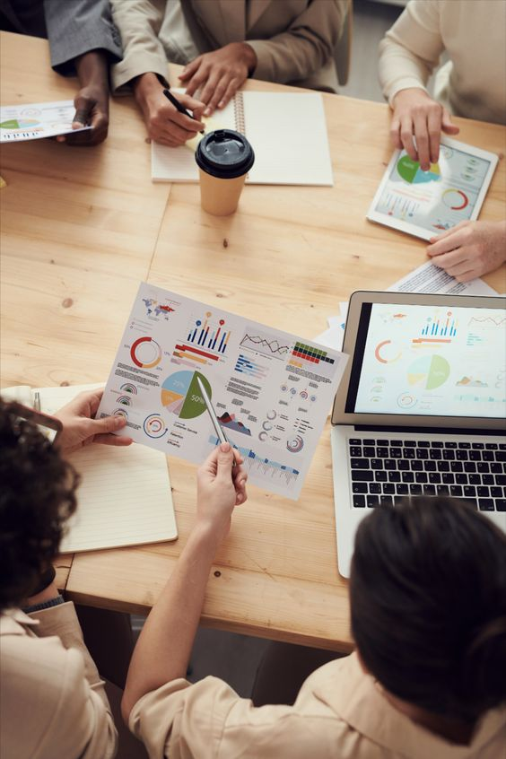

## Ventajas de RStudio

RStudio (también algunos otros editores como VSCode) integran entre sus herramientas la finalización enriquecida: podemos comenzar con una palabra y tabular (TAB) para completar, o presionar `Ctrl + espacio` para ver todas las opciones disponibles.

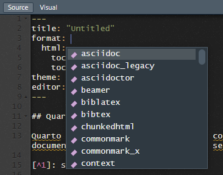

## Texto y Markdown

Inicialmente y para el uso general conviene aprovechar el `modo Visual` de RStudio para incorporar marcas de lenguaje Markdown. Prácticamente todos los elementos incorporados con formato markdown aplican en los diferentes formatos de salida (HTML, pdf, etc)

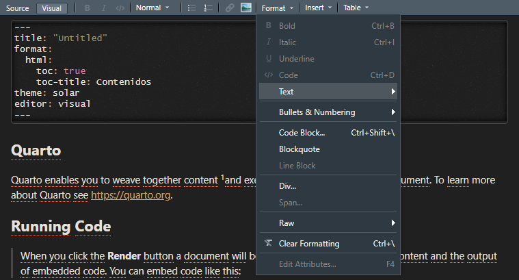

## Bloques

Pandoc y, por tanto, Quarto aceptan bloques *Divs* y *Spans* propios del HTML con sintaxis delimitada por :::

Estructura general:

- Comienza y termina con igual número de : - mínimo de 3 :::
- Agregar llaves para indicar el inicio de la clase `{.class}` o `{varias-clase}`

```
::: {style="border-left:10px solid purple"}

Este contenido tiene un diseño de borde izquierdo violeta

:::
```

*Este contenido tiene un diseño de borde izquierdo violeta*

- Se puede pensar en una división ::: como un `<div>` **HTML** pero que también sirve cuando la salida es en PDF.

## Bloques de llamadas

El formato básico de un bloque de llamadas es:

```
::: {.callout-*}
## Título del bloque

Texto incluído
:::
```

donde el * se reemplaza por el tipo de bloque. Además se puede configurar la apariencia y si se muestra o no el ícono asociado.

**Nota**

Existen cinco tipos de leyendas, que incluyen: `note` (nota), `tip` (consejo), `warning` (advertencia), `caution` (precaución), e `important` (importante)

## Bloques de llamadas

**Advertencia**

Estos bloques facilitan una forma sencilla de llamar la atención, por ejemplo, sobre esta advertencia.

**Importante**

Se pueden editar los titulos con doble #. Por ejemplo: ## Importante

**Consejo**

Tip o consejo dado

**Precaución**

Esto se encuentra bajo construcción

## Bloques de línea (Spans)

Estructura general:

- Encerrar el texto con corchetes [].
- Agregar llaves para indicar el inicio de la clase `{.class}` o `{varias-clases}`

[texto]{.class}

- Estos spans entre corchetes texto se pueden considerar como un `<span .class>Texto</span>` de **HTML** pero nuevamente estos son compatibles para aplicar atributos nativos de Pandoc/Quarto.

Este es un texto con formato [especial]{style=“color:orange;”}.

Este es un texto con formato especial.

- Tanto los Divs como los Spans se pueden agregar desde el modo Visual: *Format -> Div…* y *Format -> Span…*

## Figuras

- Sintaxis básica de markdown

![Mar del Plata](images/mdp.jpg)

Mar del Plata

## Figuras

- Sintaxis markdown con opciones

![Mar del Plata](images/mdp.jpg){width=120%}

Mar del Plata

## Figuras

- Desde código R

````markdown
```{r}
#| out-width: 50%
#| fig-align: right

knitr::include_graphics("images/mdp.jpg")
```
````

## Fragmentos / columnas

![Mar del Plata](images/mdp.jpg){fig-align=“left”}

Mar del Plata

Las columnas se construyen con bloques Divs ::: columns y luego ::: {.column width=“50%”} para cada una de ellas (en este ejemplo que son 2). Cada bloque se cierra con :::

![](images/mdp2.png){fig-align=“right” .lightbox}

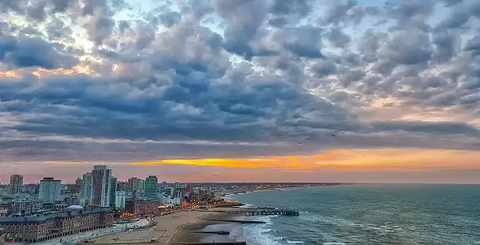

La opción `.lightbox` utiliza la librería de javascript [GLightbox](https://biati-digital.github.io/glightbox/) para mostrar un efecto sobre la imagen cuando pulsamos sobre ella.

## Pestañas (TabSet)

- Codigo
- Salida

````markdown
```{r}
#| eval: false
head(datasets::iris)
```
````

Las pestañas son un bloque Divs especiales ::: {.panel-tabset} :::

El nombre de cada pestaña se establece con **## Nombre**

Al ser dinámicas, solo funcionan en salidas HTML.

```
  Sepal.Length Sepal.Width Petal.Length Petal.Width Species
1          5.1         3.5          1.4         0.2  setosa
2          4.9         3.0          1.4         0.2  setosa
3          4.7         3.2          1.3         0.2  setosa
4          4.6         3.1          1.5         0.2  setosa
5          5.0         3.6          1.4         0.2  setosa
6          5.4         3.9          1.7         0.4  setosa
```

## Enlaces web

Existen varios tipos de “enlaces” o hipervínculos.

**Markdown**

```markdown
Se pueden insertar links en formato Markdown vinculados
a un texto como este de [Quarto](https://quarto.org/),
URL directas como <https://www.ine.gov.ar/> y
enlaces a [otros lugares](#docu-estaticos-title)
en el mismo documento.
La sintaxis es similar a incrustar un imagen en línea:
![Nombre](imagen.png).
```

**Salida**

Se pueden insertar links en formato Markdown vinculados a un texto como este de [Quarto](https://quarto.org/), URL directas como https://www.ine.gov.ar/ y enlaces a otros lugares en el mismo documento. La sintaxis es similar a incrustar un imagen en línea: .

## Listas

Listas sin orden:

**Markdown:**

```markdown
-   Lista sin orden
    -   sub-item 1
    -   sub-item 1
        -   sub-sub-item 1
```

**Salida**

- Lista sin orden
  - sub-item 1
  - sub-item 1
    - sub-sub-item 1

Listas ordenadas:

**Markdown:**

```markdown
1. Lista ordenada
2. item 2
   i. sub-item 1
      a.  sub-sub-item 1
```

**Salida**

1. Lista ordenada
2. item 2
   1. sub-item 1
      1. sub-sub-item 1

## Citas

**Markdown:**

```markdown
> Cambiemos nuestra actitud tradicional hacia la construcción
> de programas: en lugar de imaginar que nuestra tarea principal
> es indicarle a una computadora qué hacer, concentrémonos más
> bien en explicar a los seres humanos lo que queremos que haga
> una computadora. - Donald Knuth
```

**Salida:**

> Cambiemos nuestra actitud tradicional hacia la construcción de programas: en lugar de imaginar que nuestra tarea principal es indicarle a una computadora qué hacer, concentrémonos más bien en explicar a los seres humanos lo que queremos que haga una computadora. - Donald Knuth

“Literate Programming”, The Computer Journal 27 (1984), p. 97. (Reprinted in Literate Programming, 1992, p. 99.) Literate Programming (1984)

## Tablas

Tablas Markdown

**Markdown:**

```markdown
| Derecha | Izquierda | Predeterminado | Centrado |
|--------:|:----------|----------------|:--------:|
|    12   |    12     |       12       |    12    |
|   123   |   123     |      123       |   123    |
|     1   |     1     |        1       |     1    |
```

**Salida:**

| Derecha | Izquierda | Predeterminado | Centrado |
| --- | --- | --- | --- |
| 12 | 12 | 12 | 12 |
| 123 | 123 | 123 | 123 |
| 1 | 1 | 1 | 1 |

## Tablas Grid (cuadrícula)

Las tablas cuadrícula son un tipo más avanzado de tablas de Markdown que permiten otros elementos (múltiples párrafos, bloques de código, listas, etc.)

**Markdown:**

```markdown
+---------------+---------------+--------------------+
| Formato       | Extensión     | Ventajas           |
+===============+===============+====================+
| Documento     | pdf           | - Seguro           |
| portable      |               | - Universal        |
+---------------+---------------+--------------------+
| Word          | docx          | - Editable         |
|               |               | - Universal        |
+---------------+---------------+--------------------+

: Ejemplo tabla cuadrícula
```

## Tablas Grid (cuadrícula)

**Salida:**

Ejemplo tabla cuadrícula

Formato

Extensión

Ventajas

Documento portable

pdf

- Seguro
- Universal

Word

docx

- Editable
- Universal

## Tablas cuadrícula: Alineación

- Las alineaciones se pueden especificar como en las tablas anteriores, colocando dos puntos en los límites de la línea de separación después del encabezado:

```
+--------------------+---------------+--------------------+
| Derecha            | Izquierda     | Centrado           |
+===================:+:==============+:==================:+
| Documento portable | pdf           | -  Seguro          |
+--------------------+---------------+--------------------+
```

- Para tablas sin encabezado, los dos puntos van en la línea superior:

```
+--------------:+:--------------+:------------------:+
| Derecha       | Izquierda     | Centrado           |
+---------------+---------------+--------------------+
```

## Tablas cuadrícula: Creación

- Tengamos en cuenta que las tablas cuadrícula son bastante complicadas de escribir con un editor de texto plano porque, a diferencia de las tablas comunes, los indicadores de columna deben alinearse.
- ¡El Editor Visual puede ayudar a crear estas tablas! para profundizar ver [Guía Quarto](https://quarto.org/docs/visual-editor/content.html#editing-tables)
- También podemos utilizar herramientas online como [TablesGenerator](https://www.tablesgenerator.com/markdown_tables)

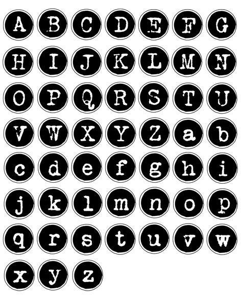

## Fórmulas

Al igual que en RMarkdown se puede insertar fórmulas matemáticas Latex en linea o en imagen completa, utilizando $ o $$ según corresponda.

- Este es un ejemplo de formula en linea $\sqrt{\frac{\alpha}{2}}$

```markdown
$\sqrt{\frac{\alpha}{2}}$
```

- La siguiente es una formula completa:

$$R(t)= A \left(\frac{E_0}{\rho_0}\right)^{1/5}t^{2/5}$$

```markdown
$$
R(t)= A \left(\frac{E_0}{\rho_0}\right)^{1/5}t^{2/5}
$$
```

## Caracteres especiales, emojis y listas de definiciones

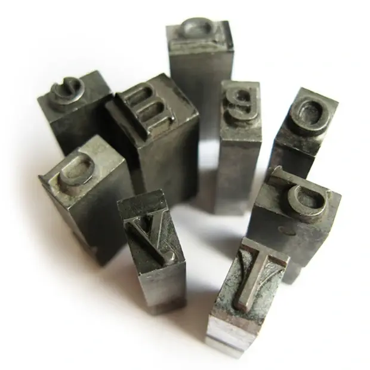

En el modo Visual se pueden insertar facilmente caracteres especiales de distinto tipo, emojis y listas de términos. Por ejemplo:

Caracteres especiales:

② ≋ 𝄞 ⍾ ◴ ⭆

Emojis:

😀 🥶 👍 🤡

Listas de definición

**Clase** en programación orientada a objetos**

Es una plantilla que define las características y comportamientos de una entidad

## Diagramas

`Quarto` tiene soporte nativo para incrustar diagramas [Mermaid](https://mermaid-js.github.io/mermaid/#/) y [Graphviz](https://graphviz.org/) . Esto permite crear diagramas de flujo, diagramas de secuencia, diagramas de estado, diagramas de Gantt y otros utilizando una sintaxis de texto plano inspirada en Markdown.

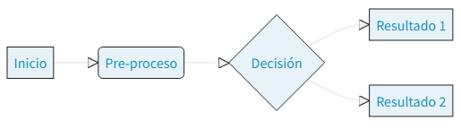

````markdown
```{{mermaid}}
flowchart LR
  A[Inicio] --> B(Pre-proceso)
  B --> C{Decisión}
  C --> D[Resultado 1]
  C --> E[Resultado 2]
```
````

- Para ver más sobre la [documentación de Mermaid.js](https://mermaid-js.github.io/mermaid/#/flowchart)

## Inclusión de código en Quarto

En todo documento Quarto se puede incluir código de diferentes lenguajes de programación (R, python, julia, javascript, etc).

Habitualmente el código sirve para mostrar resultados estadísticos en forma de tabla y/o gráfico. Otras veces el código produce diversas tareas que no se muestran hasta tanto se produzca la salida de resultados. Y en ocasiones, cuando el producto tiene un fin docente sobre el lenguaje de programación en si, se muestran las líneas de código junto a lo que produce.

Toda la ejecución del código se maneja desde las opciones de ejecución que se configuran como metadatos dentro de los fragmentos (chunks).

## Opciones de ejecución de código

Algunas de las opciones de control de ejecución de los chunck de código.

| Opción | Descripción |
| --- | --- |
| `eval` | Evalua el codigo del chunk (si es `false`, saltea el código y no lo ejecuta). |
| `echo` | Incluye el código fuente en la salida |
| `output` | Incluye el resultado de la ejecución del código en la salida (`true`, `false`, or `asis` para indicar que muestre los resultados en forma cruda). |
| `warning` | Gestiona las advertencias en la salida. |
| `error` | Gestiona los errores en la salida. |
| `include` | Evita que se incluya cualquier salida (código o resultados) (por ejemplo `include: false` suprime toda la salida del bloque de código). |
| `message` | Gestiona los mensajes en la salida |
| `fig-*` | Familia de opciones para las figuras (alto, ancho, alineación, nombre, resolución, etc) |

## Tablas desde código

Salida directa, igual que en consola y estéticamente feas.

````markdown
```{r}
library(datos)

pinguinos |>
  slice(1:6)
```
````

```
# A tibble: 6 × 8
  especie isla   largo_pico_mm alto_pico_mm largo_aleta_mm masa_corporal_g sexo
  <fct>   <fct>          <dbl>        <dbl>          <int>           <int> <fct>
1 Adelia  Torge…          39.1         18.7            181            3750 macho
2 Adelia  Torge…          39.5         17.4            186            3800 hemb…
3 Adelia  Torge…          40.3         18              195            3250 hemb…
4 Adelia  Torge…          NA           NA               NA              NA <NA>
5 Adelia  Torge…          36.7         19.3            193            3450 hemb…
6 Adelia  Torge…          39.3         20.6            190            3650 macho
# ℹ 1 more variable: anio <int>
```

## Tablas desde código

El paquete **knitr**, incuído en RStudio, puede convertir las salidas estos dataframes en tablas visuales con `knitr::kable()`:

| especie | isla | largo_pico_mm | alto_pico_mm | largo_aleta_mm | masa_corporal_g | sexo | anio |
| --- | --- | --- | --- | --- | --- | --- | --- |
| Adelia | Torgersen | 39.1 | 18.7 | 181 | 3750 | macho | 2007 |
| Adelia | Torgersen | 39.5 | 17.4 | 186 | 3800 | hembra | 2007 |
| Adelia | Torgersen | 40.3 | 18.0 | 195 | 3250 | hembra | 2007 |
| Adelia | Torgersen | NA | NA | NA | NA | NA | 2007 |
| Adelia | Torgersen | 36.7 | 19.3 | 193 | 3450 | hembra | 2007 |
| Adelia | Torgersen | 39.3 | 20.6 | 190 | 3650 | macho | 2007 |

## Tablas desde código

Existen numerosos paquetes para darle formato a las tablas producidas mediante código.

Un ejemplo muy completo es el paquete **flextable**, que vimos en clases anteriores.

Además de salidas HTML es compatible con pdf y Word (docx).

La documentación se encuentra en este [enlace](https://ardata-fr.github.io/flextable-book/)

| especie | isla | largo_pico_mm | alto_pico_mm | largo_aleta_mm | masa_corporal_g | sexo | anio |
| --- | --- | --- | --- | --- | --- | --- | --- |
| Adelia | Torgersen | 39,1 | 18,7 | 181 | 3750 | macho | 2007 |
| Adelia | Torgersen | 39,5 | 17,4 | 186 | 3800 | hembra | 2007 |
| Adelia | Torgersen | 40,3 | 18,0 | 195 | 3250 | hembra | 2007 |
| Adelia | Torgersen | N/A | N/A | N/A | N/A |  | 2007 |
| Adelia | Torgersen | 36,7 | 19,3 | 193 | 3450 | hembra | 2007 |
| Adelia | Torgersen | 39,3 | 20,6 | 190 | 3650 | macho | 2007 |

## Tablas desde código

Otro paquete para tablas elaboradas es **gt**.

Aquí podemos encontrar [todo lo que ofrece](https://gt.rstudio.com/).

| especie | isla | largo_pico_mm | alto_pico_mm | largo_aleta_mm | masa_corporal_g | sexo | anio |
| --- | --- | --- | --- | --- | --- | --- | --- |
| Adelia | Torgersen | 39.1 | 18.7 | 181 | 3750 | macho | 2007 |
| Adelia | Torgersen | 39.5 | 17.4 | 186 | 3800 | hembra | 2007 |
| Adelia | Torgersen | 40.3 | 18.0 | 195 | 3250 | hembra | 2007 |
| Adelia | Torgersen | NA | NA | NA | NA | NA | 2007 |
| Adelia | Torgersen | 36.7 | 19.3 | 193 | 3450 | hembra | 2007 |
| Adelia | Torgersen | 39.3 | 20.6 | 190 | 3650 | macho | 2007 |

## Gráficos desde código

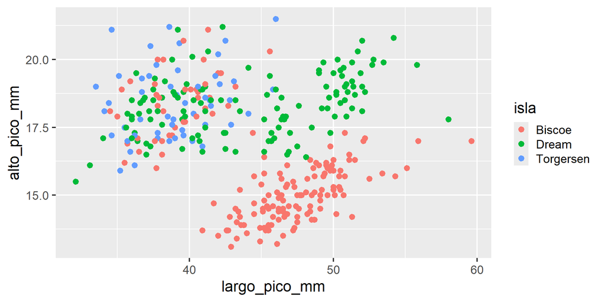

````markdown
```{r}
library(datos)
library(ggplot2)

pinguinos |>
  ggplot(aes(x = largo_pico_mm,
                     y = alto_pico_mm,
                     col = isla)) +
  geom_point()
```
````

## Ejemplo: Gráficos desde código

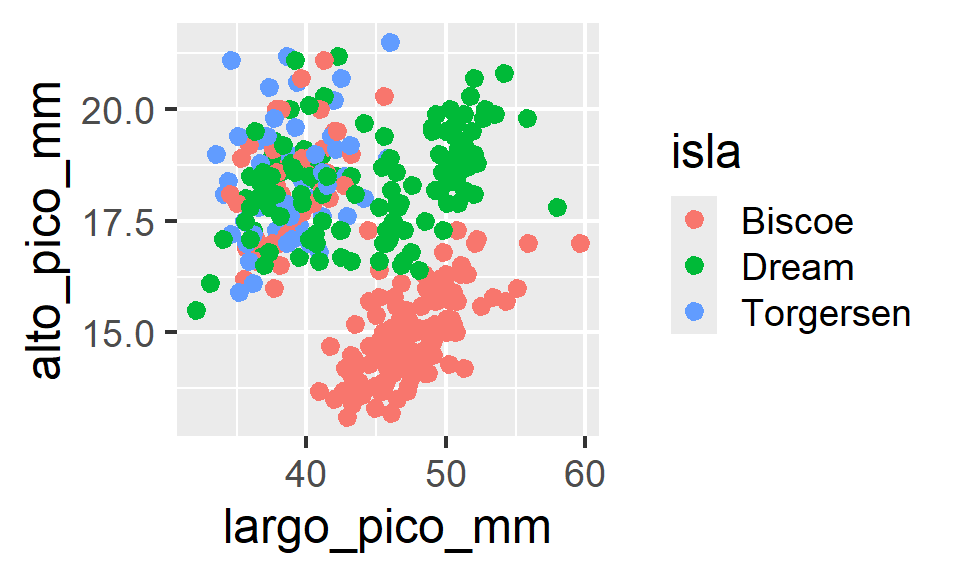

````markdown
```{r}
#| fig-width: 5
#| fig-height: 3

library(datos)
library(ggplot2)

pinguinos |>
  ggplot(aes(x = largo_pico_mm,
                     y = alto_pico_mm,
                     col = isla)) +
  geom_point()
```
````

## Ejemplo: Gráficos desde código

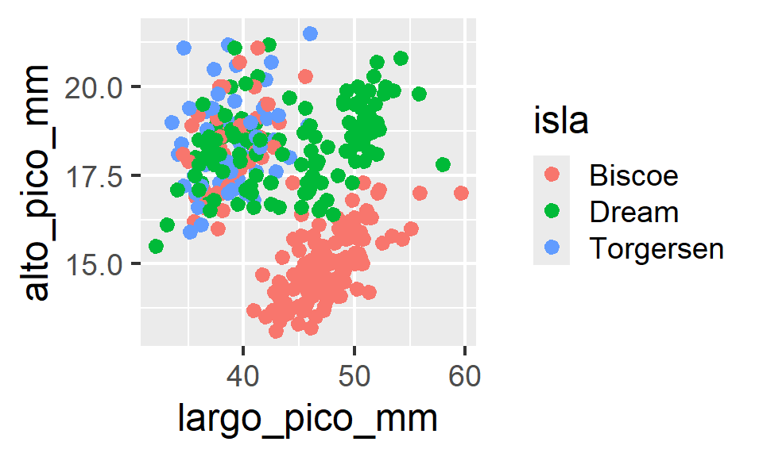

Tamaño de los pingüinos en tres islas del Archipelago Palmer.

````markdown
```{r}
#| fig-width: 5
#| fig-height: 3
#| fig-cap: "Tamaño de los pingüinos en
tres islas del Archipelago Palmer."
#| fig-alt: "Diagrama de dispersión que
muestra el tamaño de los picos de los
pingüinos en tres islas"

library(datos)
library(ggplot2)

pinguinos |>
  ggplot(aes(x = largo_pico_mm,
                     y = alto_pico_mm,
                     col = isla)) +
  geom_point()
```
````

## Temas estéticos

Los documentos HTML renderizados con Quarto usan **Bootstrap 5** de forma predeterminada. Esto se puede personalizar a través de la opción de `theme:` en la cabecera YAML.

```yaml
theme: default # bootstrap 5 predeterminado
theme: cosmo   # tema cosmo bootswatch
theme: pandoc  # tratamiento de pandoc predeterminado
theme: none    # no usa ningún tema css
```

Quarto incluye 25 temas del proyecto [Bootswatch](https://bootswatch.com/), entre los cuales se encuentran: `lumen`, `minty`, `journal`, etc.

En la cabecera YAML, junto al tema se puede definir algunas variables estéticas que se usarán al renderizar el documento, como `mainfont`, `fontsize`, `fontcolor`, etc.

```yaml
title: "Mi Documento"
format:
  html:
    theme: lumen      # tema lumen
    fontsize: 12pt    # tamaño de la fuente en 12 puntos
    fontcolor: blue   # color azul
```

## Personalización

Podemos realizar una amplia personalización de temas utilizando [Sass](https://sass-lang.com/). Existen más de 1400 variables **Sass** que controlan fuentes, colores, relleno, bordes y mucho más.

Este idioma, extensión de CSS, se utiliza en archivos `.scss` que se incluyen en la cabecera YAML.

```yaml
theme:
  - lumen
  - custom.scss
```

El contenido del archivo `custom.scss`, que debe estar ubicado en la misma carpeta donde está el `.qmd`, podría ser:

```yaml
/*-- scss:defaults --*/

$h2-font-size: 20pt;    # tamaño de fuente 20 pt en cabecera 2
$font-size-base: 12pt;  # tamaño de fuente 12 pt en texto base
$link-color: #af3434;   # color de enlace web
```

## Otros formatos de salida posibles

Editando la cabecera YAML se puede definir formatos de documentos distintos a HTML.

Entre las opciones de documentos con fines de impresión se encuentran:

- **PDF** (en base a **LaTeX**)
- **PDF** (en base a **typst**)
- **docx** (archivo **Word**)

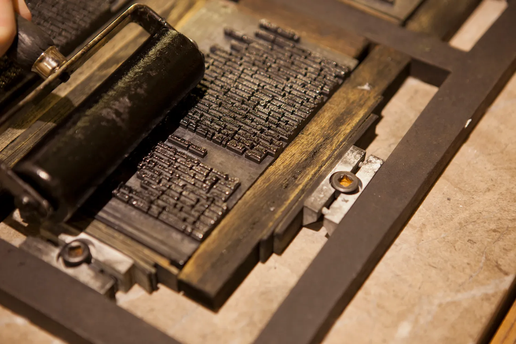

## PDF (LaTeX)

[figure not shown]

Para procesar documentos PDF de Quarto (documentos tradicionales pdf de RMarkdown) nuestra computadora debe cumplir con el requerimiento de tener instalado una distribución actualizada de **Tex**.

Existen varios motores PDF pero se recomienda utilizar [TinyTeX](https://yihui.org/tinytex/) (basado en TexLive) que podemos instalar fácilmente desde RStudio.

Otras distribuciones posibles para Windows son: **MikTex** o **Tex Live**, pero deben descargase e instalarse independientemente de RStudio.